# Maurice Wilkins Centre variants associated with Gout, T2D & BMI

Anezka Hoskin

2018-06-21

Gout tables are green.  
Diabetes tables are blue.  
BMI tables are pink.  
Significant associations are in bold.

##### New Zealand wide cohort

This cohort contains cases and controls from the Gout data base and cases from the Diabetes Mellitus (DM) and Renal Diabetes (RD) datasets. Even if subjects in the DM and RD datasets do not have diabetes or gout they can not be considered controls because they are not healthy.

All genotypes and phenotypes were extracted from SNPmax.  
The Gout genotypes and phenotypes were in the same phenogeno file. The DM and RD genotypes are in the same file but the phenotypes were seperate. Seperate phenogeno files were extracted from SNPmax and then merged in Excel. The RD rows were coppied into the DM file. The alternative ID’s of DM and RD were checked to delete duplicates in the same file and in the Gout file.

The genotypes for SLC22A3 rs8187715 variant were retrived from the CoreExome SNPmax. There are 3635 subjects present from thr Gout study, 243 sujects from Diabetes Mellitus, 248 subjects from Renal Disease and 312 from Ngati Porou Hauora. These genotypes were merged with the New Zealand wide cohort.

Once duplicates had been removed, the three dataset are merged together. The Core Exome PCA file was then merged with the NZ wide cohort file for further analyses.

##### East and West Polynesian cohorts

Sub-cohorts of East and West Polynesian groups were made from the NZ wide cohort based on the ethnicity class. Further analyses used PCA to adjust.

##### Ngati Porou Hauora cohort

The genotypes and phenotypes were downloaded from SNPmax. There are PCA values for half of the NPH cohort, in order to keep the cohort numbers analyses were adjusted with GPancestry rather than PCA.

# Significant associations summary

Gout

Type 2 Diabetes

BMI

NZW

WP

EP

NPH

NZW

WP

EP

NPH

NZW

WP

EP

NPH

LIPE

TSC1

M

WFS1

CREB3L2

SLC22A3

M

**Note:**

+ are significant associations, ‘M’ are questionablly significant.

# Variants of interest

| Gene | Gene Name | Position | Chromosome | ID | Reference | Alternative | Consequence | Annotation |
| --- | --- | --- | --- | --- | --- | --- | --- | --- |
| LIPE | Lipase E | 42405466 | 19 | rs370955937 | G | A | p.Arg821Cys | missense variant |
| TSC1 | TSC complex subunit 1 | 132905878 | 9 | rs397514880 | G | A | p.Ala567Val | missense variant |
| WFS1 | Wolframin ER transmembrane glycoprotein | 6301612 | 4 | rs756252214 | T | G | p.Val606Gly | missense variant |
| CREB3L2 | cAMP responsive element binding protein 3 like 2 | 137915992 | 7 | rs777894272 | A | G | p.Trp114Arg | missense variant |
| SLC22A3 | Solute Carrier Family 22 Member 3 | 1608647744 | 6 | rs8187715 | C | T | p.Thr44Met | missense variant |

# Cohort Demographics

Demographic data

|  | New Zealand wide | West Polynesian | East Polynesian | Ngati Porou Hauora |
| --- | --- | --- | --- | --- |
| Participants (n) | 5275 | 870 | 1458 | 561 |
| Gout, n(%) | 2438 ( 46.22 ) | 454 ( 52.18 ) | 615 ( 42.18 ) | 299 ( 53.3 ) |
| Diabetes, n(%) | 980 ( 19.66 ) | NA ( NA ) | NA ( NA ) | 116 ( 21.21 ) |
| BMI, mean (sd) | 31.81 ( 7.5 ) | 35.28 ( 7.29 ) | 33.53 ( 8.28 ) | 34.19 ( 8.06 ) |
| Sex (male), n(%) | 3385 ( 64.45 ) | 609 ( 70 ) | 799 ( 54.84 ) | 374 ( 66.67 ) |
| Age | 51.35 | 44.84 | 49.92 | 53.31 |
| Age Range | 16 - 100 | 17 - 84 | 17 - 88 | 17 - 94 |
| Height (cm) | 171.96 ( 9.52 ) | 172.67 ( 9.24 ) | 169.74 ( 9.75 ) | 169.13 ( 9.34 ) |
| Weight (kg) | 94 ( 22.88 ) | 105.27 ( 23.25 ) | 96.31 ( 24.15 ) | 97.76 ( 24.5 ) |
| Cholestrol (mmol/L) | 4.88 ( 1.18 ) | 4.8 ( 1.16 ) | 4.84 ( 1.18 ) | 5 ( 1.1 ) |
| Low Density Lipids (mmol/L) | 2.82 ( 1 ) | 2.82 ( 1.02 ) | 2.77 ( 0.99 ) | 2.92 ( 1.03 ) |
| High Density Lipids (mmol/L) | 1.18 ( 0.4 ) | 1.1 ( 0.35 ) | 1.17 ( 0.4 ) | 1.17 ( 0.33 ) |
| Triglycerides (mmol/L) | 2.11 ( 1.43 ) | 2.13 ( 1.4 ) | 2.16 ( 1.53 ) | 2.2 ( 1.53 ) |
| Serum Urate (mmol/L) | 0.43 ( 0.12 ) | 0.47 ( 0.12 ) | 0.42 ( 0.12 ) | 0.71 ( 3.38 ) |
| Serum Creatinine (umol/L) | 117.1 ( 110.43 ) | 125.5 ( 124.43 ) | 126.94 ( 145.21 ) | 94.74 ( 46.79 ) |
| HbA1c (mmol/L) | 43.43 ( 16.22 ) | 48.89 ( 20.04 ) | 43.46 ( 19.77 ) | 46.38 ( 15.57 ) |
| EGFR (mL/min/1.73 m2) | 38.84 ( 31.32 ) | 31.14 ( 29.79 ) | 30.54 ( 28.72 ) | 71.77 ( 17.22 ) |
| PCA East Polynesian, n(%) | 1148 ( 29.03 ) | 0 | 1079 ( 84.03 ) | 246 ( 83.39 ) |
| PCA West Polynesian, n(%) | 820 ( 20.74 ) | 722 ( 94.38 ) | 8 ( 0.62 ) | 6 ( 2.03 ) |

**Note:**  
Unless specified data is presented as means (sd). Estimated glomerular filtration rate (EGFR).

# Allele Frequencies and Hardy Weinburg Equilibrium

Genotype frequencies, minor allele frequencies and Hardy Weinberg

|  | New Zealand Wide Total | New Zealand Wide Gout Controls. | New Zealand Wide Gout Cases. | New Zealand Wide Diabetes Controls | New Zealand Wide Diabetes Cases | West Polynesian Total’ | West Polynesian Gout Controls.’ | West Polynesian Gout Cases.’ | West Polynesian Diabetes Controls’ | West Polynesian Diabetes Cases’ | East Polynesian ’Total | East Polynesian Gout ’Controls. | East Polynesian Gout ’Cases. | East Polynesian Diabetes ’Controls | East Polynesian Diabetes ’Cases | Ngati Porou Hauora Total, | Ngati Porou Hauora Gout ,Controls | Ngati Porou Hauora Gout ,Cases | Ngati Porou Hauora Diabetes Controls, | Ngati Porou Hauora Diabetes Cases, |
| --- | --- | --- | --- | --- | --- | --- | --- | --- | --- | --- | --- | --- | --- | --- | --- | --- | --- | --- | --- | --- |
| **LIPE (rs370955937)** |  |  |  |  |  |  |  |  |  |  |  |  |  |  |  |  |  |  |  |  |
| GG | 1501 ( 61.85 ) | 853 ( 62.58 ) | 648 ( 60.9 ) | 1069 ( 62.15 ) | 407 ( 62.14 ) | 822 ( 65.13 ) | 465 ( 63.61 ) | 357 ( 67.23 ) | 615 ( 67.14 ) | 206 ( 59.88 ) | 384 ( 48.55 ) | 188 ( 48.33 ) | 196 ( 48.76 ) | 281 ( 47.55 ) | 103 ( 51.5 ) | 350 ( 66.79 ) | 165 ( 67.9 ) | 185 ( 65.84 ) | 271 ( 67.41 ) | 72 ( 66.67 ) |
| GA | 814 ( 33.54 ) | 451 ( 33.09 ) | 363 ( 34.12 ) | 560 ( 32.56 ) | 229 ( 34.96 ) | 406 ( 32.17 ) | 244 ( 33.38 ) | 162 ( 30.51 ) | 274 ( 29.91 ) | 131 ( 38.08 ) | 335 ( 42.35 ) | 167 ( 42.93 ) | 168 ( 41.79 ) | 250 ( 42.3 ) | 85 ( 42.5 ) | 156 ( 29.77 ) | 74 ( 30.45 ) | 82 ( 29.18 ) | 121 ( 30.1 ) | 28 ( 25.93 ) |
| AA | 112 ( 4.61 ) | 59 ( 4.33 ) | 53 ( 4.98 ) | 91 ( 5.29 ) | 19 ( 2.9 ) | 34 ( 2.69 ) | 22 ( 3.01 ) | 12 ( 2.26 ) | 27 ( 2.95 ) | 7 ( 2.03 ) | 72 ( 9.1 ) | 34 ( 8.74 ) | 38 ( 9.45 ) | 60 ( 10.15 ) | 12 ( 6 ) | 18 ( 3.44 ) | 4 ( 1.65 ) | 14 ( 4.98 ) | 10 ( 2.49 ) | 8 ( 7.41 ) |
| LIPE (MAF) | 0.2138 | 0.2087 | 0.2204 | 0.2157 | 0.2038 | 0.1878 | 0.1970 | 0.1751 | 0.1790 | 0.2108 | 0.3028 | 0.3021 | 0.3035 | 0.3130 | 0.2725 | 0.1832 | 0.1687 | 0.1957 | 0.1754 | 0.2037 |
| LIPE (HWE) | 0.9039 | 1.0000 | 0.7895 | 0.1172 | 0.0539 | 0.0643 | 0.1604 | 0.2310 | 0.6539 | 0.0087 | 1.0000 | 0.8100 | 0.8139 | 0.7022 | 0.3744 | 0.8842 | 0.2525 | 0.2532 | 0.4927 | 0.0404 |
| **TSC1 (rs397514880)** |  |  |  |  |  |  |  |  |  |  |  |  |  |  |  |  |  |  |  |  |
| GG. | 1722 ( 70.06 ) | 985 ( 71.22 ) | 737 ( 68.56 ) | 1221 ( 70.09 ) | 466 ( 70.18 ) | 892 ( 69.42 ) | 524 ( 70.15 ) | 368 ( 68.4 ) | 669 ( 71.86 ) | 222 ( 63.07 ) | 508 ( 63.9 ) | 250 ( 63.94 ) | 258 ( 63.86 ) | 371 ( 62.46 ) | 137 ( 68.16 ) | 363 ( 67.72 ) | 175 ( 69.17 ) | 188 ( 66.43 ) | 281 ( 68.2 ) | 71 ( 64.55 ) |
| GA. | 662 ( 26.93 ) | 358 ( 25.89 ) | 304 ( 28.28 ) | 466 ( 26.75 ) | 181 ( 27.26 ) | 356 ( 27.7 ) | 201 ( 26.91 ) | 155 ( 28.81 ) | 234 ( 25.13 ) | 121 ( 34.38 ) | 255 ( 32.08 ) | 125 ( 31.97 ) | 130 ( 32.18 ) | 199 ( 33.5 ) | 56 ( 27.86 ) | 159 ( 29.66 ) | 73 ( 28.85 ) | 86 ( 30.39 ) | 120 ( 29.13 ) | 36 ( 32.73 ) |
| AA. | 74 ( 3.01 ) | 40 ( 2.89 ) | 34 ( 3.16 ) | 55 ( 3.16 ) | 17 ( 2.56 ) | 37 ( 2.88 ) | 22 ( 2.95 ) | 15 ( 2.79 ) | 28 ( 3.01 ) | 9 ( 2.56 ) | 32 ( 4.03 ) | 16 ( 4.09 ) | 16 ( 3.96 ) | 24 ( 4.04 ) | 8 ( 3.98 ) | 14 ( 2.61 ) | 5 ( 1.98 ) | 9 ( 3.18 ) | 11 ( 2.67 ) | 3 ( 2.73 ) |
| TSC1 (MAF) | 0.1648 | 0.1584 | 0.1730 | 0.1653 | 0.1619 | 0.1673 | 0.1640 | 0.1719 | 0.1557 | 0.1974 | 0.2006 | 0.2008 | 0.2005 | 0.2079 | 0.1791 | 0.1744 | 0.1640 | 0.1837 | 0.1723 | 0.1909 |
| TSC1 (HWE) | 0.3045 | 0.2685 | 0.6707 | 0.1935 | 1.0000 | 0.8412 | 0.5940 | 0.8802 | 0.1714 | 0.1314 | 1.0000 | 1.0000 | 1.0000 | 0.8030 | 0.4707 | 0.5512 | 0.4982 | 1.0000 | 0.8625 | 0.7588 |
| **WFS1 (rs756252214)** |  |  |  |  |  |  |  |  |  |  |  |  |  |  |  |  |  |  |  |  |
| TT | 1973 ( 80.93 ) | 1104 ( 80.53 ) | 869 ( 81.44 ) | 1405 ( 81.31 ) | 522 ( 79.33 ) | 937 ( 73.84 ) | 548 ( 74.36 ) | 389 ( 73.12 ) | 694 ( 75.43 ) | 241 ( 69.45 ) | 688 ( 86.87 ) | 330 ( 84.62 ) | 358 ( 89.05 ) | 513 ( 86.66 ) | 175 ( 87.5 ) | 348 ( 66.16 ) | 164 ( 67.21 ) | 184 ( 65.25 ) | 286 ( 70.79 ) | 56 ( 51.85 ) |
| TG | 420 ( 17.23 ) | 245 ( 17.87 ) | 175 ( 16.4 ) | 292 ( 16.9 ) | 122 ( 18.54 ) | 298 ( 23.48 ) | 171 ( 23.2 ) | 127 ( 23.87 ) | 204 ( 22.17 ) | 94 ( 27.09 ) | 96 ( 12.12 ) | 56 ( 14.36 ) | 40 ( 9.95 ) | 71 ( 11.99 ) | 25 ( 12.5 ) | 158 ( 30.04 ) | 68 ( 27.87 ) | 90 ( 31.91 ) | 103 ( 25.5 ) | 47 ( 43.52 ) |
| .GG | 45 ( 1.85 ) | 22 ( 1.6 ) | 23 ( 2.16 ) | 31 ( 1.79 ) | 14 ( 2.13 ) | 34 ( 2.68 ) | 18 ( 2.44 ) | 16 ( 3.01 ) | 22 ( 2.39 ) | 12 ( 3.46 ) | 8 ( 1.01 ) | 4 ( 1.03 ) | 4 ( 1 ) | 8 ( 1.35 ) | NA ( NA ) | 20 ( 3.8 ) | 12 ( 4.92 ) | 8 ( 2.84 ) | 15 ( 3.71 ) | 5 ( 4.63 ) |
| WFS1 (MAF) | 0.1046 | 0.1054 | 0.1036 | 0.1024 | 0.1140 | 0.1442 | 0.1404 | 0.1494 | 0.1348 | 0.1700 | 0.0707 | 0.0821 | 0.0597 | 0.0735 | 0.0625 | 0.1882 | 0.1885 | 0.1879 | 0.1646 | 0.2639 |
| WFS1 (HWE) | 0.0002 | 0.0612 | 0.0004 | 0.0015 | 0.0501 | 0.0876 | 0.2856 | 0.1708 | 0.1555 | 0.4472 | 0.0495 | 0.3122 | 0.0434 | 0.0092 | 1.0000 | 0.6698 | 0.2058 | 0.5594 | 0.1474 | 0.3204 |
| **CREB3L2 (rs777894272)** |  |  |  |  |  |  |  |  |  |  |  |  |  |  |  |  |  |  |  |  |
| .AA | 2221 ( 91.63 ) | 1269 ( 93.24 ) | 952 ( 89.56 ) | 1577 ( 91.85 ) | 595 ( 90.84 ) | 1237 ( 98.17 ) | 721 ( 98.9 ) | 516 ( 97.18 ) | 899 ( 98.36 ) | 336 ( 97.67 ) | 629 ( 79.62 ) | 315 ( 80.98 ) | 314 ( 78.3 ) | 475 ( 80.51 ) | 154 ( 77 ) | 518 ( 99.42 ) | 242 ( 99.59 ) | 276 ( 99.28 ) | 397 ( 99.5 ) | 107 ( 99.07 ) |
| AG | 198 ( 8.17 ) | 90 ( 6.61 ) | 108 ( 10.16 ) | 135 ( 7.86 ) | 60 ( 9.16 ) | 23 ( 1.83 ) | 8 ( 1.1 ) | 15 ( 2.82 ) | 15 ( 1.64 ) | 8 ( 2.33 ) | 156 ( 19.75 ) | 72 ( 18.51 ) | 84 ( 20.95 ) | 110 ( 18.64 ) | 46 ( 23 ) | 3 ( 0.58 ) | 1 ( 0.41 ) | 2 ( 0.72 ) | 2 ( 0.5 ) | 1 ( 0.93 ) |
| GG, | 5 ( 0.21 ) | 2 ( 0.15 ) | 3 ( 0.28 ) | 5 ( 0.29 ) | NA ( NA ) | NA ( NA ) | NA ( NA ) | NA ( NA ) | NA ( NA ) | NA ( NA ) | 5 ( 0.63 ) | 2 ( 0.51 ) | 3 ( 0.75 ) | 5 ( 0.85 ) | NA ( NA ) | 0 | 0 | 0 | 0 | 0 |
| CREB3L2 (MAF) | 0.0429 | 0.0345 | 0.0536 | 0.0422 | 0.0458 | 0.0091 | 0.0055 | 0.0141 | 0.0082 | 0.0116 | 0.1051 | 0.0977 | 0.1122 | 0.1017 | 0.1150 | 0 | 0 | 0 | 0 | 0 |
| CREB3L2 (HWE) | 0.8018 | 1.0000 | 1.0000 | 1.0000 | 1.0000 | 1.0000 | 1.0000 | 1.0000 | 1.0000 | 1.0000 | 0.1879 | 1.0000 | 1.0000 | 1.0000 | 1.0000 | 1.0000 | 1.0000 | 1.0000 | 1.0000 | 1.0000 |
| **SLC22A3 (rs8187715)** |  |  |  |  |  |  |  |  |  |  |  |  |  |  |  |  |  |  |  |  |
| CC | 3415 ( 87.18 ) | 1603 ( 85.72 ) | 1812 ( 88.52 ) | 2660 ( 88.61 ) | 677 ( 82.36 ) | 923 ( 72.62 ) | 530 ( 73.71 ) | 393 ( 71.2 ) | 685 ( 75.36 ) | 238 ( 66.11 ) | 633 ( 84.51 ) | 291 ( 83.62 ) | 342 ( 85.29 ) | 471 ( 82.49 ) | 162 ( 91.01 ) | 360 ( 66.54 ) | 169 ( 66.54 ) | 191 ( 66.55 ) | 277 ( 66.75 ) | 74 ( 65.49 ) |
| CT | 455 ( 11.62 ) | 241 ( 12.89 ) | 214 ( 10.45 ) | 317 ( 10.56 ) | 127 ( 15.45 ) | 307 ( 24.15 ) | 165 ( 22.95 ) | 142 ( 25.72 ) | 202 ( 22.22 ) | 104 ( 28.89 ) | 113 ( 15.09 ) | 55 ( 15.8 ) | 58 ( 14.46 ) | 97 ( 16.99 ) | 16 ( 8.99 ) | 160 ( 29.57 ) | 77 ( 30.31 ) | 83 ( 28.92 ) | 124 ( 29.88 ) | 32 ( 28.32 ) |
| TT., | 47 ( 1.2 ) | 26 ( 1.39 ) | 21 ( 1.03 ) | 25 ( 0.83 ) | 18 ( 2.19 ) | 41 ( 3.23 ) | 24 ( 3.34 ) | 17 ( 3.08 ) | 22 ( 2.42 ) | 18 ( 5 ) | 3 ( 0.4 ) | 2 ( 0.57 ) | 1 ( 0.25 ) | 3 ( 0.53 ) | 0 ( 0 ) | 21 ( 3.88 ) | 8 ( 3.15 ) | 13 ( 4.53 ) | 14 ( 3.37 ) | 7 ( 6.19 ) |
| SLC22A3 (MAF) | 0.0701 | 0.0783 | 0.0625 | 0.0611 | 0.0991 | 0.1530 | 0.1481 | 0.1594 | 0.1353 | 0.1944 | 0.0794 | 0.0848 | 0.0748 | 0.0902 | 0.0449 | 0.1867 | 0.1831 | 0.1899 | 0.1831 | 0.2035 |
| SLC22A3 (HWE) | 0.0000 | 0.0000 | 0.0000 | 0.0001 | 0.0005 | 0.0171 | 0.0178 | 0.3409 | 0.1543 | 0.1329 | 0.6138 | 1.0000 | 0.7133 | 0.6079 | 1.0000 | 0.0000 | 0.0000 | 0.0000 | 0.0000 | 0.0000 |

**Note:**  
Minor allele frequency (MAF), Hardy Weinberg Equilibrium (HWE)

# Gout

### New Zealand Wide Cohort

Gout associations in New Zealand wide cohort

| SNP | n | genotypes | alleles | Unadjusted Beta | Unadjusted SE | Unadjusted OR | Unadjusted LowerCI | Unadjusted UpperCI | Unadjusted P | Adjusted n.adj | Adjusted Beta.adj | Adjusted SE.adj | Adjusted OR.adj | Adjusted LowerCI.adj | Adjusted UpperCI.adj | Adjusted P.adj |
| --- | --- | --- | --- | --- | --- | --- | --- | --- | --- | --- | --- | --- | --- | --- | --- | --- |
| LIPE (rs370955937) | 2427 | 1501/814/112 | GG/GA/AA | 0.069 | 0.070 | 1.072 | 0.933 | 1.230 | 0.326 | 2172 | -0.138 | 0.095 | 0.871 | 0.723 | 1.049 | 0.146 |
| TSC1 (rs397514880) | 2458 | 1722/662/74 | GG/GA/AA | 0.104 | 0.076 | 1.110 | 0.955 | 1.289 | 0.174 | 2195 | -0.113 | 0.100 | 0.893 | 0.734 | 1.086 | 0.258 |
| WFS1 (rs756252214) | 2438 | 1973/420/45 | TT/TG/GG | -0.018 | 0.091 | 0.982 | 0.821 | 1.173 | 0.842 | 2179 | -0.017 | 0.117 | 0.983 | 0.782 | 1.237 | 0.886 |
| CREB3L2 (rs777894272) | 2424 | 2221/198/5 | AA/AG/GG | 0.459 | 0.143 | 1.582 | 1.198 | 2.096 | 0.001 | 2169 | 0.069 | 0.193 | 1.072 | 0.735 | 1.567 | 0.720 |
| SLC22A3 (rs8187715) | 3917 | 3415/455/47 | CC/CT/TT | -0.219 | 0.084 | 0.803 | 0.680 | 0.948 | 0.010 | 3766 | -0.023 | 0.109 | 0.977 | 0.789 | 1.209 | 0.832 |

**Note:**  
Adjusted by age, sex, BMI and PC’s 1-10 and broad PCA ethnicity

##### Adjusted without BMI

Adjusted associations WITHOUT BMI

| SNP | n.adj | genotypes.adj | alleles.adj | Beta.adj | SE.adj | OR.adj | LowerCI.adj | UpperCI.adj | P.adj |
| --- | --- | --- | --- | --- | --- | --- | --- | --- | --- |
| LIPE (rs370955937) | 2239 | 1501/814/112 | GG/GA/AA | -0.080 | 0.091 | 0.923 | 0.772 | 1.103 | 0.377 |
| TSC1 (rs397514880) | 2263 | 1722/662/74 | GG/GA/AA | -0.087 | 0.096 | 0.917 | 0.759 | 1.107 | 0.365 |
| WFS1 (rs756252214) | 2247 | 1973/420/45 | TT/TG/GG | -0.087 | 0.112 | 0.917 | 0.735 | 1.143 | 0.441 |
| CREB3L2 (rs777894272) | 2236 | 2221/198/5 | AA/AG/GG | 0.091 | 0.189 | 1.096 | 0.757 | 1.589 | 0.629 |
| SLC22A3 (rs8187715) | 3891 | 3415/455/47 | CC/CT/TT | -0.026 | 0.103 | 0.974 | 0.795 | 1.193 | 0.801 |

**Note:**  
Adjusted by age, sex and PC’s 1-10 and broad PCA ethnicity

### West Polynesian

Gout associations in West Polynesian

| SNP | n | genotypes | alleles | Unadjusted Beta | Unadjusted SE | Unadjusted OR | Unadjusted LowerCI | Unadjusted UpperCI | Unadjusted P | Adjusted n.adj | Adjusted Beta.adj | Adjusted SE.adj | Adjusted OR.adj | Adjusted LowerCI.adj | Adjusted UpperCI.adj | Adjusted P.adj |
| --- | --- | --- | --- | --- | --- | --- | --- | --- | --- | --- | --- | --- | --- | --- | --- | --- |
| LIPE (rs370955937) | 791 | 384/335/72 | GG/GA/AA | 0.007 | 0.110 | 1.007 | 0.812 | 1.248 | 0.951 | 710 | -0.106 | 0.141 | 0.899 | 0.682 | 1.185 | 0.452 |
| TSC1 (rs397514880) | 795 | 508/255/32 | GG/GA/AA | -0.002 | 0.125 | 0.998 | 0.781 | 1.277 | 0.989 | 713 | -0.061 | 0.159 | 0.941 | 0.689 | 1.285 | 0.702 |
| WFS1 (rs756252214) | 792 | 688/96/8 | TT/TG/GG | -0.318 | 0.192 | 0.727 | 0.497 | 1.055 | 0.096 | 710 | -0.232 | 0.235 | 0.793 | 0.498 | 1.254 | 0.323 |
| CREB3L2 (rs777894272) | 790 | 629/156/5 | AA/AG/GG | 0.163 | 0.169 | 1.177 | 0.846 | 1.643 | 0.334 | 709 | -0.020 | 0.214 | 0.980 | 0.643 | 1.493 | 0.924 |
| SLC22A3 (rs8187715) | 749 | 633/113/3 | CC/CT/TT | -0.140 | 0.194 | 0.869 | 0.593 | 1.273 | 0.470 | 730 | -0.058 | 0.232 | 0.943 | 0.598 | 1.490 | 0.801 |

**Note:**  
Adjusted by age, sex, BMI, PC’s 1-4 and broad PCA ethnicity

##### Adjusted without BMI

Adjusted associations WITHOUT BMI

| SNP | n.adj | genotypes.adj | alleles.adj | Beta.adj | SE.adj | OR.adj | LowerCI.adj | UpperCI.adj | P.adj |
| --- | --- | --- | --- | --- | --- | --- | --- | --- | --- |
| LIPE (rs370955937) | 728 | 384/335/72 | GG/GA/AA | -0.013 | 0.133 | 0.988 | 0.761 | 1.282 | 0.925 |
| TSC1 (rs397514880) | 731 | 508/255/32 | GG/GA/AA | -0.108 | 0.153 | 0.898 | 0.665 | 1.212 | 0.481 |
| WFS1 (rs756252214) | 728 | 688/96/8 | TT/TG/GG | -0.294 | 0.223 | 0.745 | 0.479 | 1.152 | 0.188 |
| CREB3L2 (rs777894272) | 727 | 629/156/5 | AA/AG/GG | -0.064 | 0.209 | 0.938 | 0.623 | 1.413 | 0.759 |
| SLC22A3 (rs8187715) | 749 | 633/113/3 | CC/CT/TT | -0.101 | 0.223 | 0.904 | 0.584 | 1.403 | 0.651 |

**Note:**  
Adjusted by age, sex and PC’s 1-4 and broad PCA ethnicity

### East Polynesian

Gout associations in East Polynesian

| SNP | n | genotypes | alleles | Unadjusted Beta | Unadjusted SE | Unadjusted OR | Unadjusted LowerCI | Unadjusted UpperCI | Unadjusted P | Adjusted n.adj | Adjusted Beta.adj | Adjusted SE.adj | Adjusted OR.adj | Adjusted LowerCI.adj | Adjusted UpperCI.adj | Adjusted P.adj |
| --- | --- | --- | --- | --- | --- | --- | --- | --- | --- | --- | --- | --- | --- | --- | --- | --- |
| LIPE (rs370955937) | 1262 | 822/406/34 | GG/GA/AA | -0.153 | 0.107 | 0.858 | 0.695 | 1.058 | 0.154 | 1157 | -0.333 | 0.138 | 0.717 | 0.546 | 0.939 | 0.016 |
| TSC1 (rs397514880) | 1285 | 892/356/37 | GG/GA/AA | 0.057 | 0.107 | 1.058 | 0.858 | 1.303 | 0.596 | 1176 | -0.095 | 0.138 | 0.909 | 0.693 | 1.192 | 0.491 |
| WFS1 (rs756252214) | 1269 | 937/298/34 | TT/TG/GG | 0.069 | 0.111 | 1.072 | 0.861 | 1.333 | 0.534 | 1163 | -0.003 | 0.139 | 0.997 | 0.759 | 1.311 | 0.985 |
| CREB3L2 (rs777894272) | 1260 | 1237/23 | AA/AG | 0.963 | 0.442 | 2.620 | 1.129 | 6.550 | 0.029 | 1155 | 1.440 | 0.643 | 4.222 | 1.269 | 15.801 | 0.025 |
| SLC22A3 (rs8187715) | 1271 | 923/307/41 | CC/CT/TT | 0.081 | 0.107 | 1.085 | 0.879 | 1.338 | 0.448 | 1237 | -0.020 | 0.133 | 0.980 | 0.755 | 1.271 | 0.880 |

**Note:**  
Adjusted by age, sex, BMI, PC’s 1-4 and broad PCA ethnicity

##### Adjusted without BMI

Adjusted associations WITHOUT BMI

| SNP | n.adj | genotypes.adj | alleles.adj | Beta.adj | SE.adj | OR.adj | LowerCI.adj | UpperCI.adj | P.adj |
| --- | --- | --- | --- | --- | --- | --- | --- | --- | --- |
| LIPE (rs370955937) | 1186 | 822/406/34 | GG/GA/AA | -0.276 | 0.134 | 0.759 | 0.583 | 0.985 | 0.039 |
| TSC1 (rs397514880) | 1205 | 892/356/37 | GG/GA/AA | -0.018 | 0.132 | 0.982 | 0.757 | 1.273 | 0.891 |
| WFS1 (rs756252214) | 1192 | 937/298/34 | TT/TG/GG | -0.068 | 0.134 | 0.934 | 0.717 | 1.216 | 0.614 |
| CREB3L2 (rs777894272) | 1184 | 1237/23 | AA/AG/GG | 1.596 | 0.590 | 4.933 | 1.592 | 16.167 | 0.007 |
| SLC22A3 (rs8187715) | 1269 | 923/307/41 | CC/CT/TT | -0.017 | 0.127 | 0.983 | 0.766 | 1.261 | 0.893 |

**Note:**  
Adjusted by age, sex and PC’s 1-4 and broad PCA ethnicity

### Ngati Porou Hauora

Gout associations in Ngati Porou Hauora

[output not shown]

**Note:**  
Adjusted by age, sex, BMI and GPancestry

##### Adjusted without BMI

Adjusted associations WITHOUT BMI

| SNP | n.adj | genotypes.adj | alleles.adj | Beta.adj | SE.adj | OR.adj | LowerCI.adj | UpperCI.adj | P.adj |
| --- | --- | --- | --- | --- | --- | --- | --- | --- | --- |
| LIPE (rs370955937) | 518 | 350/156/18 | GG/GA/AA | 0.259 | 0.184 | 1.296 | 0.906 | 1.866 | 0.159 |
| TSC1 (rs397514880) | 530 | 363/159/14 | GG/GA/AA | 0.335 | 0.195 | 1.398 | 0.956 | 2.059 | 0.087 |
| WFS1 (rs756252214) | 520 | 348/158/20 | TT/TG/GG | -0.005 | 0.179 | 0.995 | 0.701 | 1.415 | 0.976 |
| SLC22A3 (rs8187715) | 535 | 360/160/21 | CC/CT/TT | 0.048 | 0.177 | 1.049 | 0.743 | 1.489 | 0.787 |

**Note:**  
Adjusted by age, sex and GPancestry

# Type 2 Diabetes

### New Zealand Wide Cohort

Type 2 diabetes association in New Zealand wide cohort

| SNP | n | genotypes | alleles | Unadjusted Beta | Unadjusted SE | Unadjusted OR | Unadjusted LowerCI | Unadjusted UpperCI | Unadjusted P | Adjusted n.adj | Adjusted Beta.adj | Adjusted SE.adj | Adjusted OR.adj | Adjusted LowerCI.adj | Adjusted UpperCI.adj | Adjusted P.adj |
| --- | --- | --- | --- | --- | --- | --- | --- | --- | --- | --- | --- | --- | --- | --- | --- | --- |
| LIPE (rs370955937) | 2375 | 1477/790/110 | GG/GA/AA | -0.071 | 0.080 | 0.931 | 0.795 | 1.088 | 0.373 | 2125 | -0.181 | 0.101 | 0.835 | 0.684 | 1.016 | 0.074 |
| TSC1 (rs397514880) | 2406 | 1688/648/72 | GG/GA/AA | -0.025 | 0.086 | 0.976 | 0.822 | 1.154 | 0.776 | 2148 | -0.071 | 0.105 | 0.932 | 0.757 | 1.143 | 0.501 |
| WFS1 (rs756252214) | 2386 | 1929/414/45 | TT/TG/GG | 0.111 | 0.099 | 1.117 | 0.917 | 1.354 | 0.265 | 2132 | 0.003 | 0.120 | 1.003 | 0.791 | 1.267 | 0.978 |
| CREB3L2 (rs777894272) | 2372 | 2174/195/5 | AA/AG/GG | 0.085 | 0.157 | 1.088 | 0.795 | 1.471 | 0.589 | 2122 | 0.048 | 0.201 | 1.049 | 0.703 | 1.546 | 0.811 |
| SLC22A3 (rs8187715) | 3824 | 3338/445/44 | CC/CT/TT | 0.476 | 0.094 | 1.609 | 1.336 | 1.932 | 0.000 | 3706 | -0.008 | 0.114 | 0.992 | 0.792 | 1.240 | 0.947 |

**Note:**  
Adjusted by age, sex, BMI and PC’s 1-10 and broad PCA ethnicity

##### Adjusted without BMI

Adjusted associations WITHOUT BMI

| SNP | n.adj | genotypes.adj | alleles.adj | Beta.adj | SE.adj | OR.adj | LowerCI.adj | UpperCI.adj | P.adj |
| --- | --- | --- | --- | --- | --- | --- | --- | --- | --- |
| LIPE (rs370955937) | 2188 | 1477/790/110 | GG/GA/AA | -0.125 | 0.098 | 0.882 | 0.728 | 1.067 | 0.200 |
| TSC1 (rs397514880) | 2212 | 1688/648/72 | GG/GA/AA | -0.050 | 0.103 | 0.951 | 0.777 | 1.162 | 0.628 |
| WFS1 (rs756252214) | 2196 | 1929/414/45 | TT/TG/GG | -0.017 | 0.117 | 0.983 | 0.781 | 1.233 | 0.885 |
| CREB3L2 (rs777894272) | 2185 | 2174/195/5 | AA/AG/GG | 0.028 | 0.198 | 1.028 | 0.692 | 1.507 | 0.888 |
| SLC22A3 (rs8187715) | 3809 | 3338/445/44 | CC/CT/TT | 0.044 | 0.110 | 1.045 | 0.841 | 1.295 | 0.689 |

**Note:**  
Adjusted by age, sex and PC’s 1-10 and broad PCA ethnicity

### West Polynesian

Type 2 diabetes associations in West Polynesian

| SNP | n | genotypes | alleles | Unadjusted Beta | Unadjusted SE | Unadjusted OR | Unadjusted LowerCI | Unadjusted UpperCI | Unadjusted P | Adjusted n.adj | Adjusted Beta.adj | Adjusted SE.adj | Adjusted OR.adj | Adjusted LowerCI.adj | Adjusted UpperCI.adj | Adjusted P.adj |
| --- | --- | --- | --- | --- | --- | --- | --- | --- | --- | --- | --- | --- | --- | --- | --- | --- |
| LIPE (rs370955937) | 791 | 384/335/72 | GG/GA/AA | -0.197 | 0.129 | 0.821 | 0.636 | 1.055 | 0.127 | 710 | -0.242 | 0.168 | 0.785 | 0.562 | 1.087 | 0.150 |
| TSC1 (rs397514880) | 795 | 508/255/32 | GG/GA/AA | -0.185 | 0.149 | 0.831 | 0.617 | 1.107 | 0.213 | 713 | -0.175 | 0.186 | 0.840 | 0.579 | 1.204 | 0.348 |
| WFS1 (rs756252214) | 792 | 688/96/8 | TT/TG/GG | -0.162 | 0.227 | 0.851 | 0.534 | 1.306 | 0.476 | 710 | -0.239 | 0.280 | 0.788 | 0.448 | 1.346 | 0.393 |
| CREB3L2 (rs777894272) | 790 | 629/156/5 | AA/AG/GG | 0.145 | 0.189 | 1.157 | 0.792 | 1.666 | 0.442 | 709 | -0.125 | 0.244 | 0.882 | 0.541 | 1.410 | 0.607 |
| SLC22A3 (rs8187715) | 749 | 633/113/3 | CC/CT/TT | -0.767 | 0.280 | 0.464 | 0.259 | 0.781 | 0.006 | 730 | -0.851 | 0.312 | 0.427 | 0.225 | 0.771 | 0.006 |

**Note:**  
Adjusted by age, sex, BMI, PC’s 1-4 and broad PCA ethnicity

##### Adjusted without BMI

Adjusted associations WITHOUT BMI

| SNP | n.adj | genotypes.adj | alleles.adj | Beta.adj | SE.adj | OR.adj | LowerCI.adj | UpperCI.adj | P.adj |
| --- | --- | --- | --- | --- | --- | --- | --- | --- | --- |
| LIPE (rs370955937) | 728 | 384/335/72 | GG/GA/AA | -0.013 | 0.133 | 0.988 | 0.761 | 1.282 | 0.925 |
| TSC1 (rs397514880) | 731 | 508/255/32 | GG/GA/AA | -0.108 | 0.153 | 0.898 | 0.665 | 1.212 | 0.481 |
| WFS1 (rs756252214) | 728 | 688/96/8 | TT/TG/GG | -0.294 | 0.223 | 0.745 | 0.479 | 1.152 | 0.188 |
| CREB3L2 (rs777894272) | 727 | 629/156/5 | AA/AG/GG | -0.064 | 0.209 | 0.938 | 0.623 | 1.413 | 0.759 |
| SLC22A3 (rs8187715) | 749 | 633/113/3 | CC/CT/TT | -0.101 | 0.223 | 0.904 | 0.584 | 1.403 | 0.651 |

**Note:**  
Adjusted by age, sex and PC’s 1-4 and broad PCA ethnicity

### East Polynesian

Type 2 diabetes associations in East Polynesian

| SNP | n | genotypes | alleles | Unadjusted Beta | Unadjusted SE | Unadjusted OR | Unadjusted LowerCI | Unadjusted UpperCI | Unadjusted P | Adjusted n.adj | Adjusted Beta.adj | Adjusted SE.adj | Adjusted OR.adj | Adjusted LowerCI.adj | Adjusted UpperCI.adj | Adjusted P.adj |
| --- | --- | --- | --- | --- | --- | --- | --- | --- | --- | --- | --- | --- | --- | --- | --- | --- |
| LIPE (rs370955937) | 1260 | 822/406/34 | GG/GA/AA | 0.215 | 0.115 | 1.240 | 0.988 | 1.552 | 0.062 | 1155 | -0.022 | 0.137 | 0.978 | 0.747 | 1.278 | 0.874 |
| TSC1 (rs397514880) | 1283 | 892/356/37 | GG/GA/AA | 0.287 | 0.114 | 1.332 | 1.063 | 1.665 | 0.012 | 1174 | 0.166 | 0.135 | 1.180 | 0.905 | 1.535 | 0.219 |
| WFS1 (rs756252214) | 1267 | 937/298/34 | TT/TG/GG | 0.261 | 0.119 | 1.299 | 1.026 | 1.638 | 0.028 | 1161 | 0.102 | 0.138 | 1.107 | 0.842 | 1.450 | 0.462 |
| CREB3L2 (rs777894272) | 1258 | 1237/23 | AA/AG/GG | 0.356 | 0.442 | 1.427 | 0.570 | 3.316 | 0.422 | 1153 | 0.405 | 0.529 | 1.500 | 0.508 | 4.147 | 0.443 |
| SLC22A3 (rs8187715) | 1269 | 923/307/41 | CC/CT/TT | 0.408 | 0.114 | 1.504 | 1.202 | 1.878 | 0.000 | 1235 | 0.166 | 0.130 | 1.180 | 0.914 | 1.521 | 0.202 |

**Note:**  
Adjusted by age, sex, BMI, PC’s 1-4 and broad PCA ethnicity

##### Adjusted without BMI

Adjusted associations WITHOUT BMI

| SNP | n.adj | genotypes.adj | alleles.adj | Beta.adj | SE.adj | OR.adj | LowerCI.adj | UpperCI.adj | P.adj |
| --- | --- | --- | --- | --- | --- | --- | --- | --- | --- |
| LIPE (rs370955937) | 1184 | 822/406/34 | GG/GA/AA | 0.051 | 0.130 | 1.053 | 0.814 | 1.357 | 0.694 |
| TSC1 (rs397514880) | 1203 | 892/356/37 | GG/GA/AA | 0.196 | 0.129 | 1.216 | 0.942 | 1.566 | 0.130 |
| WFS1 (rs756252214) | 1190 | 937/298/34 | TT/TG/GG | 0.069 | 0.132 | 1.072 | 0.825 | 1.387 | 0.601 |
| CREB3L2 (rs777894272) | 1182 | 1237/23 | AA/AG/GG | 0.617 | 0.500 | 1.853 | 0.668 | 4.841 | 0.217 |
| SLC22A3 (rs8187715) | 1267 | 923/307/41 | CC/CT/TT | 0.225 | 0.124 | 1.252 | 0.981 | 1.596 | 0.070 |

**Note:**  
Adjusted by age, sex and PC’s 1-4 and broad PCA ethnicity

### Ngati Porou Hauora

Type 2 diabetes association in Ngati Porou Hauora

| SNP | n | genotypes | alleles | Unadjusted Beta | Unadjusted SE | Unadjusted OR | Unadjusted LowerCI | Unadjusted UpperCI | Unadjusted P | Adjusted n.adj | Adjusted Beta.adj | Adjusted SE.adj | Adjusted OR.adj | Adjusted LowerCI.adj | Adjusted UpperCI.adj | Adjusted P.adj |
| --- | --- | --- | --- | --- | --- | --- | --- | --- | --- | --- | --- | --- | --- | --- | --- | --- |
| LIPE (rs370955937) | 510 | 343/149/18 | GG/GA/AA | 0.182 | 0.191 | 1.199 | 0.818 | 1.736 | 0.342 | 481 | 0.168 | 0.216 | 1.182 | 0.769 | 1.800 | 0.438 |
| TSC1 (rs397514880) | 522 | 352/156/14 | GG/GA/AA | 0.129 | 0.198 | 1.138 | 0.765 | 1.667 | 0.515 | 489 | -0.016 | 0.234 | 0.984 | 0.616 | 1.550 | 0.946 |
| WFS1 (rs756252214) | 512 | 342/150/20 | TT/TG/GG | 0.586 | 0.181 | 1.796 | 1.256 | 2.563 | 0.001 | 483 | 0.659 | 0.215 | 1.934 | 1.267 | 2.950 | 0.002 |
| SLC22A3 (rs8187715) | 528 | 351/156/21 | CC/CT/TT | 0.127 | 0.185 | 1.136 | 0.783 | 1.623 | 0.493 | 496 | 0.122 | 0.208 | 1.130 | 0.747 | 1.692 | 0.558 |

**Note:**  
Adjusted by age, sex, BMI and GPancestry

##### Adjusted without BMI

Adjusted associations WITHOUT BMI

| SNP | n.adj | genotypes.adj | alleles.adj | Beta.adj | SE.adj | OR.adj | LowerCI.adj | UpperCI.adj | P.adj |
| --- | --- | --- | --- | --- | --- | --- | --- | --- | --- |
| LIPE (rs370955937) | 504 | 343/149/18 | GG/GA/AA | 0.315 | 0.205 | 1.370 | 0.913 | 2.042 | 0.124 |
| TSC1 (rs397514880) | 516 | 352/156/14 | GG/GA/AA | 0.028 | 0.214 | 1.028 | 0.671 | 1.556 | 0.896 |
| WFS1 (rs756252214) | 506 | 342/150/20 | TT/TG/GG | 0.696 | 0.199 | 2.005 | 1.356 | 2.970 | 0.000 |
| SLC22A3 (rs8187715) | 522 | 351/156/21 | CC/CT/TT | 0.079 | 0.193 | 1.083 | 0.736 | 1.575 | 0.681 |

**Note:**  
Adjusted by age, sex and GPancestry

# BMI

### New Zealand Wide

Linear regression of BMI. Covariates in the adjusted model are age, sex, PCs 1-10 and broad ethnicity

| test | unadjusted n | unadjusted estimate | unadjusted std.error | unadjusted statistic | unadjusted p.value | adjusted n_adj | adjusted estimate_adj | adjusted std.error_adj | adjusted statistic_adj | adjusted p.value_adj |
| --- | --- | --- | --- | --- | --- | --- | --- | --- | --- | --- |
|  | NA | NA | NA | NA | NA | NA | NA | NA | NA | NA |
| LIPE (rs370955937) | 2353 | 2.042 | 0.281 | 7.264 | 5.096 x 10<sup>-13</sup> | 2172 | 0.827 | 0.302 | 2.735 | 0.006 |
| TSC1 (rs397514880) | 2383 | 1.278 | 0.306 | 4.176 | 3.079 x 10<sup>-5</sup> | 2195 | 0.298 | 0.321 | 0.928 | 0.353 |
| WFS1 (rs756252214) | 2363 | -0.190 | 0.364 | -0.523 | 0.601 | 2179 | -1.037 | 0.376 | -2.754 | 0.006 |
| CREB3L2 (rs777894272) | 2350 | 1.615 | 0.571 | 2.830 | 0.005 | 2169 | 0.087 | 0.613 | 0.142 | 0.887 |
| SLC22A3 (rs8187715) | 3777 | 2.784 | 0.321 | 8.670 | 6.304 x 10<sup>-18</sup> | 3766 | 0.414 | 0.327 | 1.265 | 0.206 |

### West Polynesian

Linear regression of BMI. Covariates in the adjusted model are age, sex, PCs 1-4 and broad ethnicity

| test | unadjusted n | unadjusted estimate | unadjusted std.error | unadjusted statistic | unadjusted p.value | adjusted n_adj | adjusted estimate_adj | adjusted std.error_adj | adjusted statistic_adj | adjusted p.value_adj |
| --- | --- | --- | --- | --- | --- | --- | --- | --- | --- | --- |
|  | NA | NA | NA | NA | NA | NA | NA | NA | NA | NA |
| LIPE (rs370955937) | 767 | 0.886 | 0.399 | 2.222 | 0.027 | 710 | 0.845 | 0.415 | 2.033 | 0.042 |
| TSC1 (rs397514880) | 771 | -0.365 | 0.454 | -0.802 | 0.423 | 713 | -0.482 | 0.479 | -1.006 | 0.315 |
| WFS1 (rs756252214) | 768 | -0.698 | 0.688 | -1.014 | 0.311 | 710 | -0.682 | 0.700 | -0.974 | 0.331 |
| CREB3L2 (rs777894272) | 766 | -0.303 | 0.610 | -0.497 | 0.619 | 709 | -0.450 | 0.640 | -0.704 | 0.482 |
| SLC22A3 (rs8187715) | 730 | 0.331 | 0.703 | 0.471 | 0.638 | 730 | 0.177 | 0.706 | 0.251 | 0.802 |

### East Polynesian

Linear regression of BMI. Covariates in the adjusted model are age, sex, PCs 1-4 and broad ethnicity

| test | unadjusted n | unadjusted estimate | unadjusted std.error | unadjusted statistic | unadjusted p.value | adjusted n_adj | adjusted estimate_adj | adjusted std.error_adj | adjusted statistic_adj | adjusted p.value_adj |
| --- | --- | --- | --- | --- | --- | --- | --- | --- | --- | --- |
|  | NA | NA | NA | NA | NA | NA | NA | NA | NA | NA |
| LIPE (rs370955937) | 1232 | 1.608 | 0.435 | 3.698 | 2.269 x 10<sup>-4</sup> | 1157 | 0.877 | 0.463 | 1.895 | 0.058 |
| TSC1 (rs397514880) | 1255 | 1.412 | 0.436 | 3.237 | 0.001 | 1176 | 0.968 | 0.462 | 2.094 | 0.037 |
| WFS1 (rs756252214) | 1239 | -0.320 | 0.459 | -0.697 | 0.486 | 1163 | -1.113 | 0.477 | -2.331 | 0.020 |
| CREB3L2 (rs777894272) | 1230 | 4.524 | 1.807 | 2.504 | 0.012 | 1155 | 3.957 | 1.835 | 2.157 | 0.031 |
| SLC22A3 (rs8187715) | 1239 | 1.169 | 0.448 | 2.609 | 0.009 | 1237 | 0.508 | 0.455 | 1.117 | 0.264 |

### Ngati Porou

Linear regression of BMI. Covariates in the adjusted model are age, sex and GPancestry

| test | unadjusted n | unadjusted estimate | unadjusted std.error | unadjusted statistic | unadjusted p.value | adjusted n_adj | adjusted estimate_adj | adjusted std.error_adj | adjusted statistic_adj | adjusted p.value_adj |
| --- | --- | --- | --- | --- | --- | --- | --- | --- | --- | --- |
|  | NA | NA | NA | NA | NA | NA | NA | NA | NA | NA |
| LIPE (rs370955937) | 498 | 1.183 | 0.661 | 1.790 | 0.074 | 493 | 1.343 | 0.670 | 2.005 | 0.045 |
| TSC1 (rs397514880) | 506 | 0.124 | 0.689 | 0.179 | 0.858 | 501 | 0.139 | 0.701 | 0.198 | 0.843 |
| WFS1 (rs756252214) | 500 | 1.528 | 0.650 | 2.350 | 0.019 | 495 | 1.752 | 0.661 | 2.649 | 0.008 |
| SLC22A3 (rs8187715) | 513 | -0.218 | 0.638 | -0.341 | 0.733 | 508 | -0.088 | 0.642 | -0.137 | 0.891 |

# Meta Analyses

These meta-analyses are comparing the logistic regression results of East, West and Ngati Porou Hauora cohorts.

## Gout

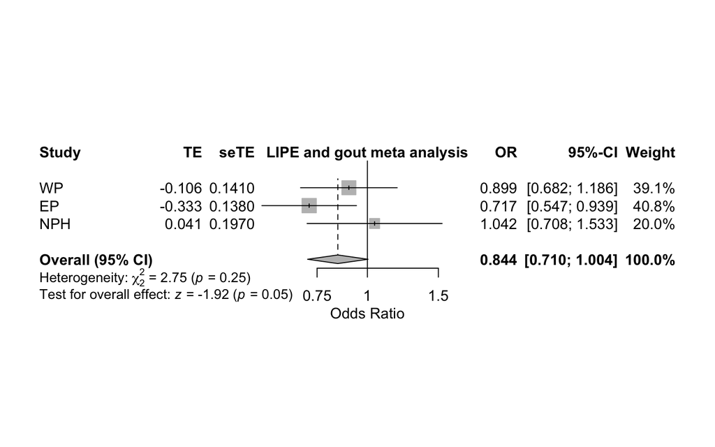

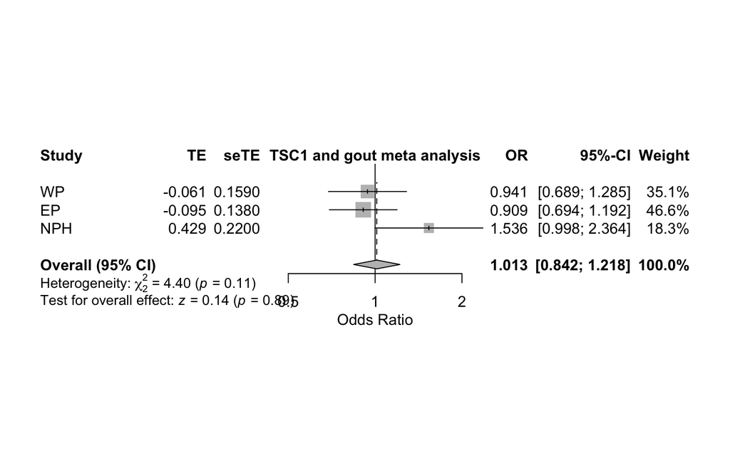

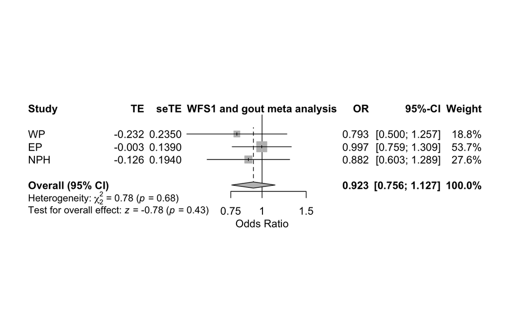

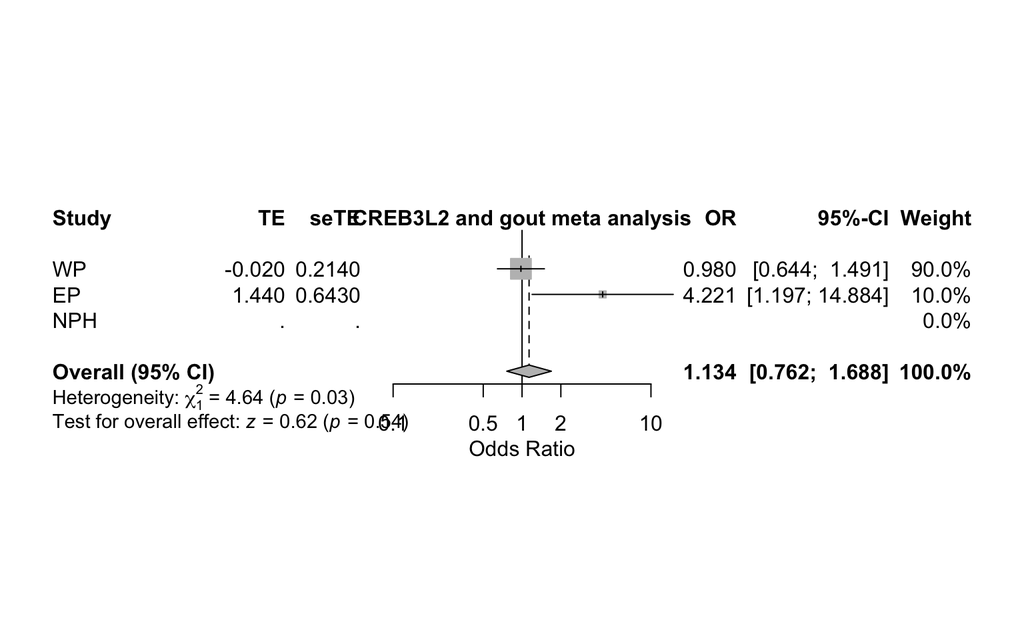

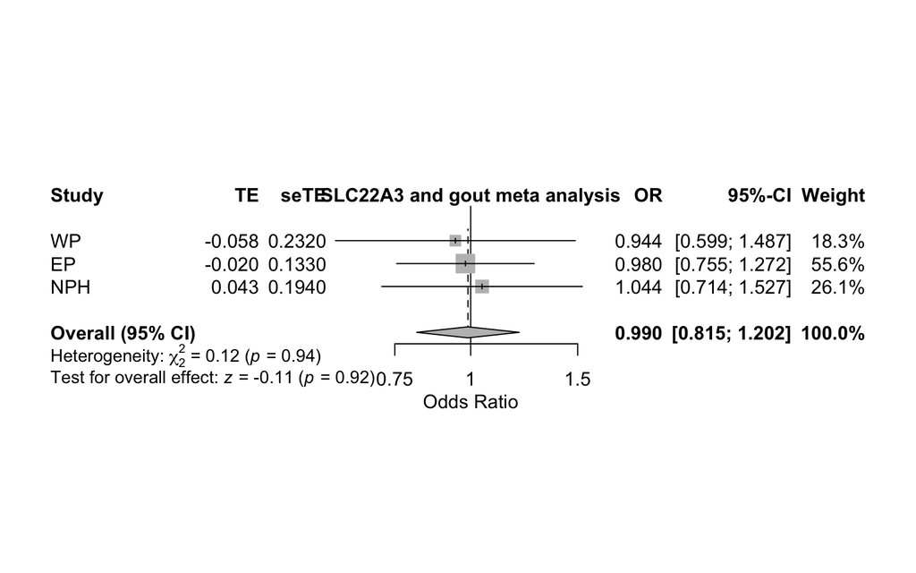

## Diabetes

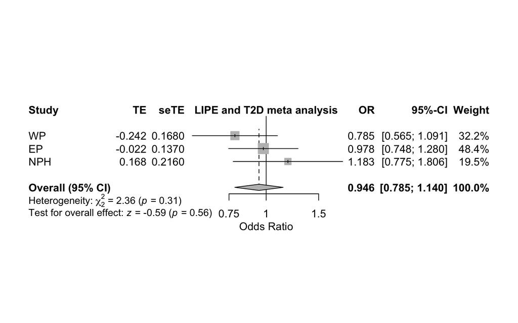

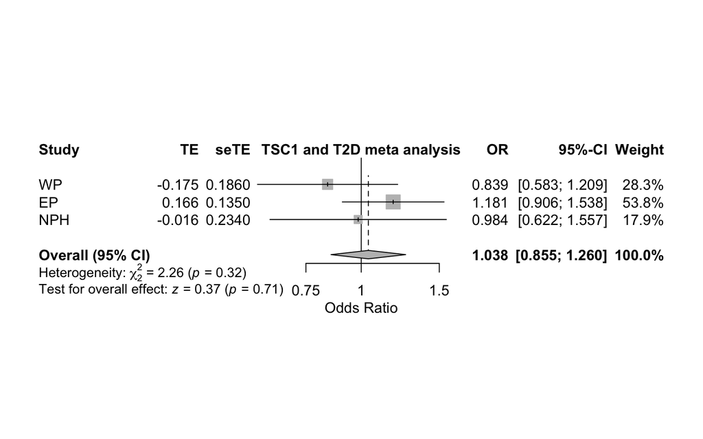

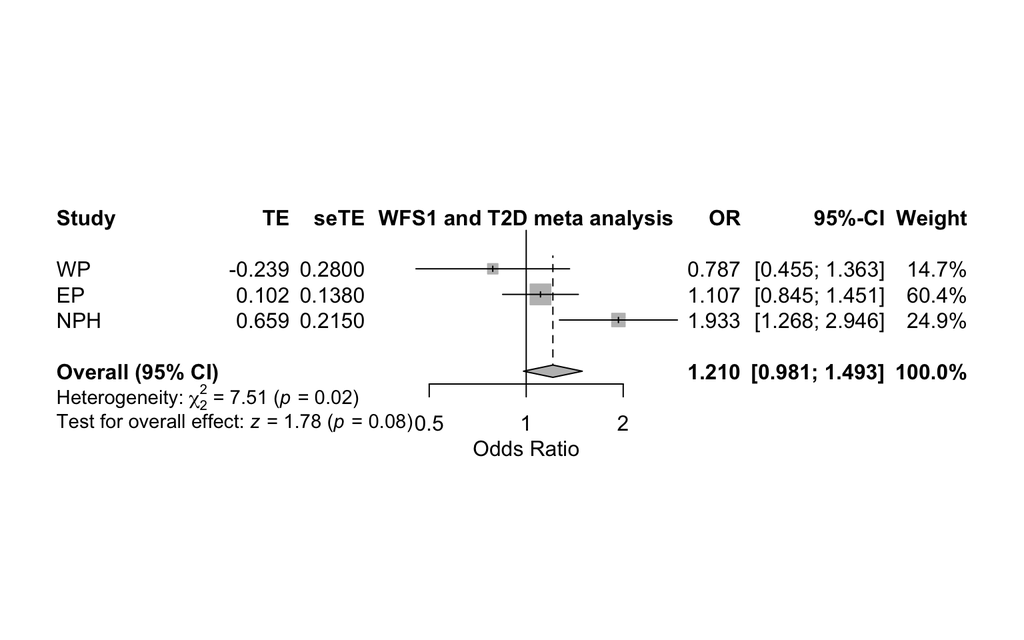

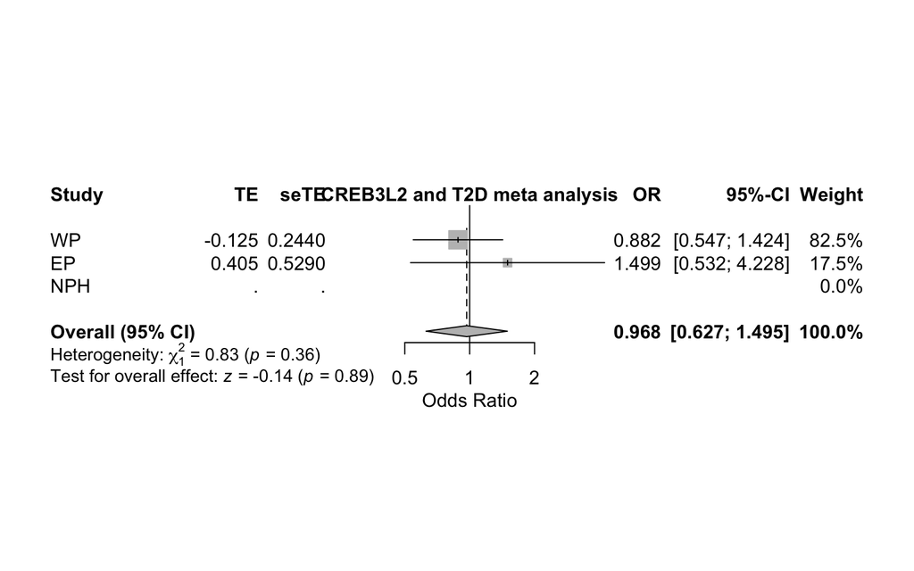

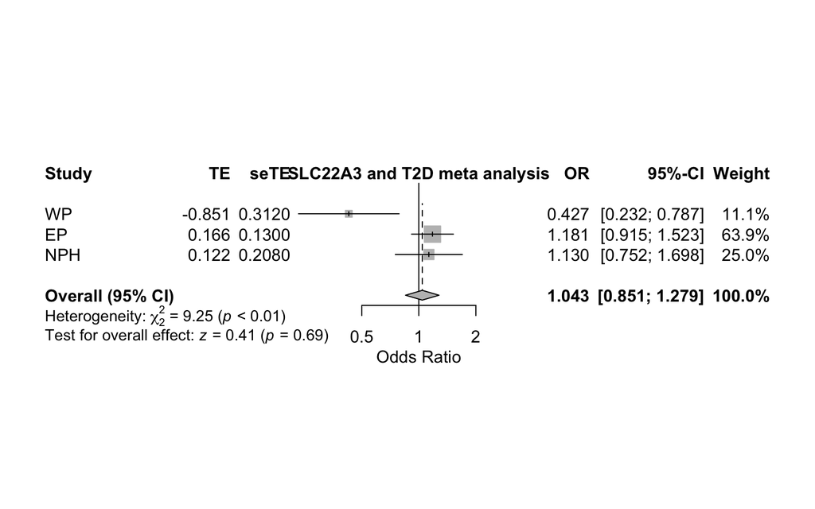

## BMI

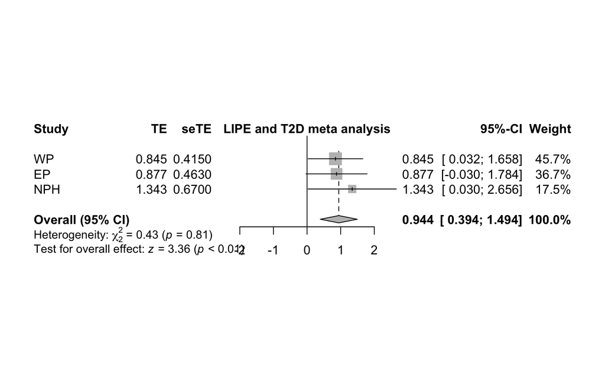

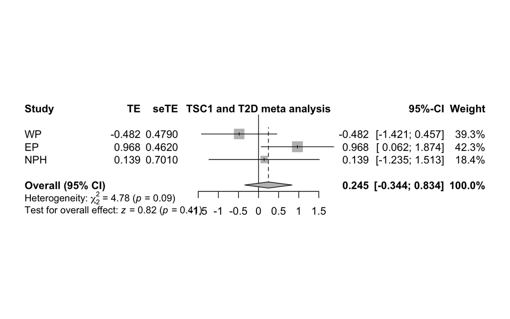

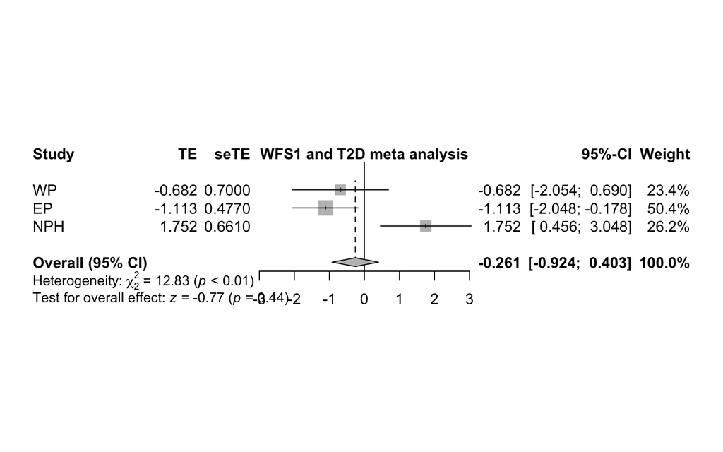

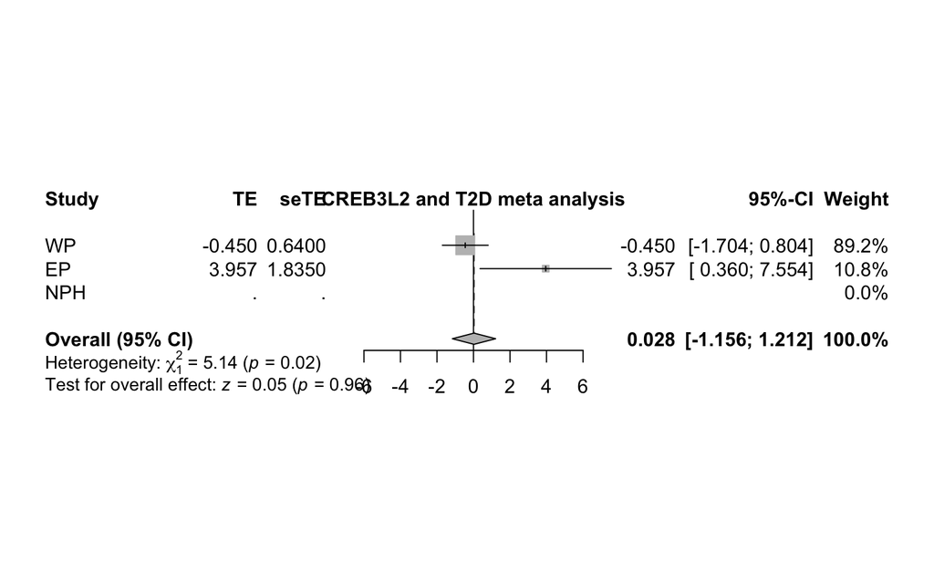

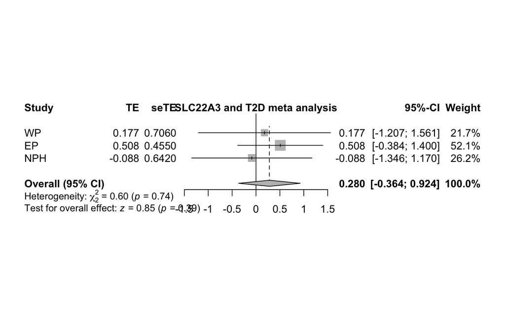